# Tsukuba.Rへようこそ

Shinya Uryu (@u_ribo)

2018-10-20

去る10月7日、およそ7年ぶりとなるTsukuba.Rが[つくばイノベーションプラザ](http://www.city.tsukuba.lg.jp/shisetsu/shiminseikatsu/1002800.html)にて[開催されました](https://www.meetup.com/ja-JP/TsukubaR/events/254321674/)[^1]。運営メンバーも刷新ということもあり、新生Tsukuba.Rとして再起動となります。イベントのナンバリングも#1と改めました。

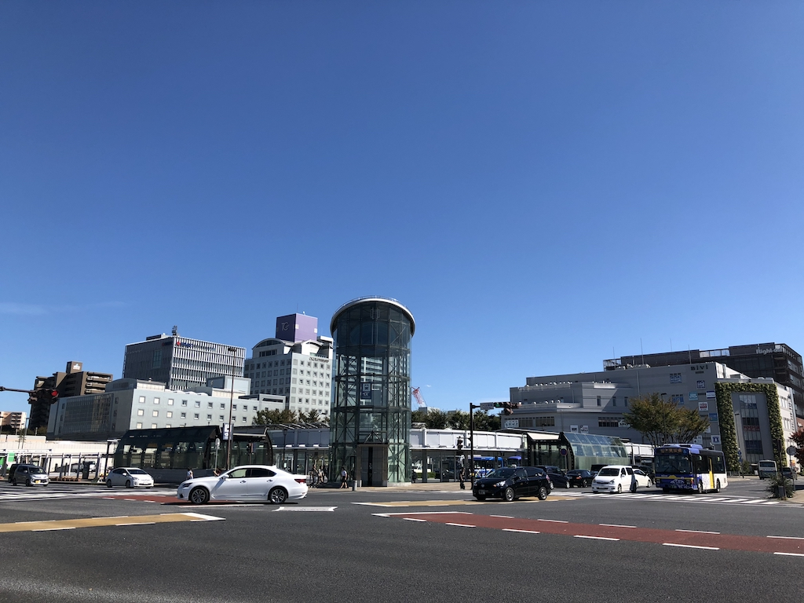

つくばへようこそ！

立ち上げの回となった今回は、Tsukuba.Rのコミュニティとしてのあり方や今後の運営について議論する回でした。 ゲストスピーカーとして[@kilometer00](http://twitter.com/kilometer00) さんにトークしていただり、LTや飛び込みでの発表があったりと賑わいました。

この記事では当日発表のあった資料と回の様子（主にTwitterからの実況）について報告します。話し合った内容についての詳細は[GitHub Issues](https://github.com/tsukubar/hq/issues)にまとめています。

> はじまったぞ！ [#tsukubar](https://twitter.com/hashtag/tsukubar?src=hash&ref_src=twsrc%5Etfw)

> — kilometer (@kilometer00) [October 7, 2018](https://twitter.com/kilometer00/status/1048788392106807302?ref_src=twsrc%5Etfw)

> [#TsukubaR](https://twitter.com/hashtag/TsukubaR?src=hash&ref_src=twsrc%5Etfw)  
> つくばR、はじまりました～！パチパチ

> — niszet📚技術書典5 い04でした (@niszet0) [October 7, 2018](https://twitter.com/niszet0/status/1048788304051621888?ref_src=twsrc%5Etfw)

記念すべき？最初のつぶやき。

## Guest Talk Sessoion

国内のRコミュニティとして、もっとも規模が大きく歴史も長いTokyo.Rの運営メンバーを務めている[@kilometer00](http://twitter.com/kilometer00)さん。話していただいたテーマは「初心者セッションを行う際のコンセプト」です。

[@kilometer00](http://twitter.com/kilometer00)さんはここ数回のTokyo.Rの初心者セッションで毎回発表されています。行動神経科学を専門に研究されていることもあり、とてもわかりやすく、私自身もなるほど、と何度も納得してしまいました。

初めてRを触る、プログラミングをする人たちに対して、どのように考え方から伝えていく際の知見について学べました。

> 昨日のハイライトです。 [#tsukubar](https://twitter.com/hashtag/tsukubar?src=hash&ref_src=twsrc%5Etfw) [pic.twitter.com/w4tDkzhtTn](https://t.co/w4tDkzhtTn)

> — kilometer (@kilometer00) [October 8, 2018](https://twitter.com/kilometer00/status/1049186446077120513?ref_src=twsrc%5Etfw)

> [@kilometer00](https://twitter.com/kilometer00?ref_src=twsrc%5Etfw) さんの話からは、誰かに何かを教える際に気をつけていることやコツを学べました。実例を取り上げ、比較すること。そうすれば確かにわかりやすいかもしれないと感じました。  
> Tokyo.R運営の話も、コミュニティ活動の参考になる点が豊富でした。  
> （無茶をお願いしてしまってすみません）

> — Uryu Shinya (@u_ribo) [October 7, 2018](https://twitter.com/u_ribo/status/1048872731054227457?ref_src=twsrc%5Etfw)

## Meeting session

一部抜粋です。

- Rコミュニティではあるけど、Rだけにこだわらず、「つくば」周辺の学生、研究者、データ分析に携わる人の交流の場を目指したい
  - 回のテーマは言語を問わずに。Python, Julia、なんでもこい。
- 一回の時間は数時間（平日）から半日（休日）。発表者は2,3人。時間が余ればもくもく会として自由時間に充てるのが良い。
- イベントページとして[meetup](https://www.meetup.com/ja-JP/TsukubaR/)を用意したが、日本人ユーザにはconnpassの方が馴染みがある。Tokyo.Rでの導入事例もあるので移行を検討する。

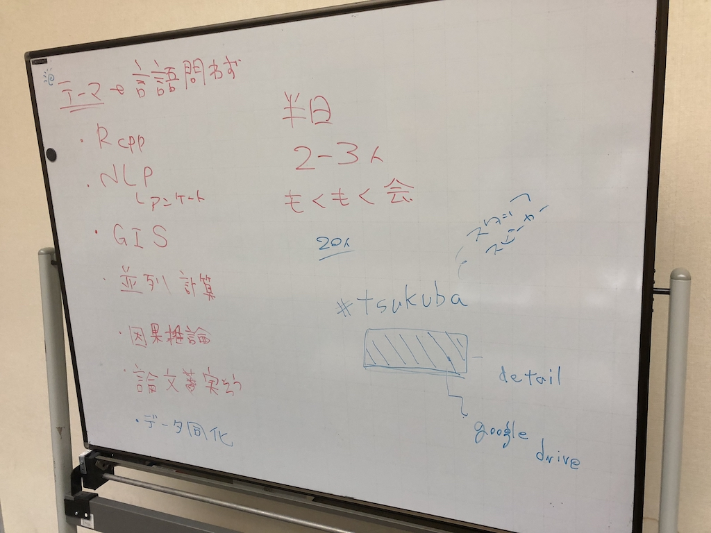

テーマ回に関する議論の様子

## Lighting Talk Session

> 唐突に超豪華ベイズ入門！ [#tsukubar](https://twitter.com/hashtag/tsukubar?src=hash&ref_src=twsrc%5Etfw)

> — kilometer (@kilometer00) [October 7, 2018](https://twitter.com/kilometer00/status/1048814910442893317?ref_src=twsrc%5Etfw)

> サプライズでしたが、気になったポイントをその場で質問できるし、じっくり解説してもらえるし、お得感たっぷりでした😁1000×ありがとうございます！！ https://t.co/xI0R8mfnNi

> — Uryu Shinya (@u_ribo) [October 7, 2018](https://twitter.com/u_ribo/status/1048874643291951104?ref_src=twsrc%5Etfw)

> 突貫LTで技術書典のお話 [#tsukubar](https://twitter.com/hashtag/tsukubar?src=hash&ref_src=twsrc%5Etfw)

> — kilometer (@kilometer00) [October 7, 2018](https://twitter.com/kilometer00/status/1048824384008282113?ref_src=twsrc%5Etfw)

> [@niszet0](https://twitter.com/niszet0?ref_src=twsrc%5Etfw) さんは、明日 [#技術書店](https://twitter.com/hashtag/%E6%8A%80%E8%A1%93%E6%9B%B8%E5%BA%97?src=hash&ref_src=twsrc%5Etfw) で販売される「R MarkdownでWord文書を作ろう」の制作秘話とR Markdownでパワポ（⁉️）を作るという話を聞けました。とても実用的な話でした。表紙は要チェックです👀

> — Uryu Shinya (@u_ribo) [October 7, 2018](https://twitter.com/u_ribo/status/1048874159898423296?ref_src=twsrc%5Etfw)

> RMarkdown（pandoc）でパワポ作るの便利そう。昔紹介したのはこちら。 [#tsukubaR](https://twitter.com/hashtag/tsukubaR?src=hash&ref_src=twsrc%5Etfw) https://t.co/wsFFbn62nI

> — Kentaro Matsuura (@hankagosa) [October 7, 2018](https://twitter.com/hankagosa/status/1048827784766709760?ref_src=twsrc%5Etfw)

## 祭りの後に…

> tsukubaR楽しかったな。遅刻して入ったらどう見てもボルダリングの説明してて面食らったけど、初心者への教え方論でもっと早めから聞きたかったわい。 [#tsukubaR](https://twitter.com/hashtag/tsukubaR?src=hash&ref_src=twsrc%5Etfw)

> — Kentaro Matsuura (@hankagosa) [October 7, 2018](https://twitter.com/hankagosa/status/1048858670778343425?ref_src=twsrc%5Etfw)

> 筑波大学に変態的なRユーザがいるというタレコミも得た

> — Uryu Shinya (@u_ribo) [October 7, 2018](https://twitter.com/u_ribo/status/1048881330627342339?ref_src=twsrc%5Etfw)

> Tsukuba.R#1 おしまい！参加された方ありがとうございました。  
> 今後のコミュニティ運営を考えるための議論や相談ができてよかったです。  
> 開始前、参加者数に不安がありましたが、蓋を開けてみれば学生の参加もあり、企業、研究機関、大学という多様な人たちが交流できる場となっていて安堵しました。

> — Uryu Shinya (@u_ribo) [October 7, 2018](https://twitter.com/u_ribo/status/1048871294266105856?ref_src=twsrc%5Etfw)

> 今後が楽しみな会でした！ありがとうございました！ https://t.co/GhsoCJ2jPl

> — nakaizumi (@iOut3) [October 7, 2018](https://twitter.com/iOut3/status/1048880483164086274?ref_src=twsrc%5Etfw)
[^1]: 前進となるTsukuba.Rの#9が2011年11月に開催されてから